# crystal-solvent_molecules

```python
import pandas as pd
import numpy as np
import matplotlib.pyplot as plt
import matplotlib as mpl
import seaborn as sns
import scipy

from math import ceil

%matplotlib inline
```

```python
sns.set_context('talk')
```

```python
from statsmodels.sandbox.stats.multicomp import multipletests
from scipy.stats import pearsonr, spearmanr
```

```python
df = pd.read_csv('crystal-solvent_descriptors_delta_upd.txt', sep='\t', index_col=0)
```

Рассмотрим подвыборку пар полиморфов, для которых различия в конформации молекул в кристалле, выраженные в значении среднеквадратичного отклонения атомных позиций (RMSD), относительно невелики: RMSD < 0.375Å

```python
correlation_df = df.query('RMSD < 0.375')
```

```python
start = 6
N = 18
correlation_df.columns[start:N]
```

```
Index(['Zprime', 'packing_coefficient', 'TD10_mean', 'CN_mean', 'HB_net_dim',
       'HB_TD10_mean', 'HB_CN_mean', 'num_HB_mean', 'QC_px', 'Qd_stab_px',
       'Qcp_stab_px', 'Q_sr_px'],
      dtype='object')
```

```python
correlation_df.shape
```

```
(190, 80)
```

Рассчитаем значения пирсоновкой корреляции для 12х62 = 744 пар разностей дескрипторов кристаллическая структура - молекула растворителя

```python
%%time

res = []

for cryst_desc_column in correlation_df.columns[start:N]:
    for solv_desc_column in correlation_df.columns[N:]:

        cdf = correlation_df[[solv_desc_column, cryst_desc_column, 'HB_possible']].dropna()

        if 'HB' in cryst_desc_column:
            cdf = cdf[cdf['HB_possible'] == True]

        solvent = cdf[solv_desc_column]
        crystal = cdf[cryst_desc_column]

        r, p_val = pearsonr(crystal, solvent)
        res.append([cryst_desc_column, solv_desc_column, cdf.shape[0], r, p_val])
```

```
Wall time: 1.58 s
```

```python
corr_df = pd.DataFrame(res, columns=['crystal desc', 'solvent desc', 'N', 'Pearsons r', 'p_value'])
rejected, p_corr, _, _ = multipletests(corr_df['p_value'], alpha = 0.05, method = 'bonferroni')

corr_df['p_value_corr'] = p_corr
corr_df['rejected'] = rejected
```

```python
corr_df.sort_values(by=['p_value_corr', 'p_value'], ascending=True).head(10)
```

|  | crystal desc | solvent desc | N | Pearsons r | p_value | p_value_corr | rejected |
| --- | --- | --- | --- | --- | --- | --- | --- |
| 120 | packing_coefficient | dipole moment, D | 189 | 0.317579 | 0.000008 | 0.006305 | True |
| 92 | packing_coefficient | TopoPSA | 190 | 0.272323 | 0.000144 | 0.107203 | False |
| 216 | CN_mean | TopoPSA | 190 | 0.264725 | 0.000223 | 0.166212 | False |
| 244 | CN_mean | dipole moment, D | 189 | 0.259968 | 0.000303 | 0.225564 | False |
| 526 | QC_px | TopoPSA | 160 | -0.276529 | 0.000401 | 0.298031 | False |
| 93 | packing_coefficient | nHBAcc | 190 | 0.251055 | 0.000476 | 0.354227 | False |
| 43 | Zprime | alpha_Abraham | 188 | 0.251135 | 0.000508 | 0.378227 | False |
| 251 | HB_net_dim | ETA_dEpsilon_A | 138 | -0.288286 | 0.000606 | 0.450915 | False |
| 154 | TD10_mean | TopoPSA | 190 | 0.241353 | 0.000795 | 0.591346 | False |
| 217 | CN_mean | nHBAcc | 190 | 0.234518 | 0.001127 | 0.838274 | False |

```python
dist = []
dist.append(corr_df['Pearsons r'].values)
```

Рассчитаем значения ранговой корреляции Спирмена для 12х62 = 744 пар разностей дескрипторов кристаллическая структура - молекула растворителя

```python
%%time
res = []

for cryst_desc_column in correlation_df.columns[start:N]:
    for solv_desc_column in correlation_df.columns[N:]:

        cdf = correlation_df[[solv_desc_column, cryst_desc_column, 'HB_possible']].dropna()

        if 'HB' in cryst_desc_column:
            cdf = cdf[cdf['HB_possible'] == True]

        solvent = cdf[solv_desc_column]
        crystal = cdf[cryst_desc_column]

        r, p_val = spearmanr(crystal, solvent)
        res.append([cryst_desc_column, solv_desc_column, cdf.shape[0], r, p_val])
```

```
Wall time: 1.98 s
```

```python
corr_df = pd.DataFrame(res, columns=['crystal desc', 'solvent desc', 'N',  'Spearmans rho', 'p_value'])
rejected, p_corr, _, _ = multipletests(corr_df['p_value'], alpha = 0.05, method = 'bonferroni')

corr_df['p_value_corr'] = p_corr
corr_df['rejected'] = rejected
```

```python
corr_df.sort_values(by=['p_value_corr', 'p_value'], ascending=True).head(10)
```

|  | crystal desc | solvent desc | N | Spearmans rho | p_value | p_value_corr | rejected |
| --- | --- | --- | --- | --- | --- | --- | --- |
| 216 | CN_mean | TopoPSA | 190 | 0.334053 | 0.000002 | 0.001841 | True |
| 244 | CN_mean | dipole moment, D | 189 | 0.307166 | 0.000017 | 0.012752 | True |
| 93 | packing_coefficient | nHBAcc | 190 | 0.303860 | 0.000020 | 0.015074 | True |
| 154 | TD10_mean | TopoPSA | 190 | 0.293399 | 0.000040 | 0.029652 | True |
| 120 | packing_coefficient | dipole moment, D | 189 | 0.289166 | 0.000054 | 0.040528 | True |
| 217 | CN_mean | nHBAcc | 190 | 0.287846 | 0.000056 | 0.042018 | True |
| 92 | packing_coefficient | TopoPSA | 190 | 0.284611 | 0.000069 | 0.051311 | False |
| 526 | QC_px | TopoPSA | 160 | -0.305274 | 0.000087 | 0.064451 | False |
| 255 | HB_net_dim | FNSA1 | 138 | -0.318163 | 0.000143 | 0.106410 | False |
| 670 | Qcp_stab_px | HSP_p | 158 | -0.278353 | 0.000398 | 0.296223 | False |

Видим, что для шести пар разностей дескрипторов достигаемый уровень значимости величины коэфициента корреляции Спирмена меньше 0.05, что говорит о статистической значимости найденных корреляций

```python
dist.append(corr_df['Spearmans rho'].values)
```

```python
corr_df.shape
```

```
(744, 7)
```

```python
dist_df = pd.DataFrame(dist, index=[r'$r$', r'$\rho$']).T
```

Покажем гистограммы рассчитанных коэффициентов корреляции Пирсона (слева) и Спирмена (справа) между 744 парами значений разностей дескрипторов (descriptor differences), описывающих кристаллические структур и молекулы растворителя

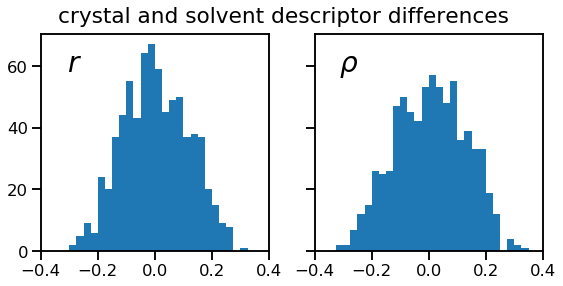

```python
fig, ax = plt.subplots(nrows=1, ncols=2, figsize=(9, 4), sharey=True)

ax[0].hist(dist_df[r'$r$'], bins=np.arange(-0.4, 0.4, 0.025))
ax[0].set_xlim(-0.4, 0.4)
ax[0].set_title(r'$r$', x=0.15, y=0.8, fontsize=28)
ax[1].hist(dist_df[r'$\rho$'], bins=np.arange(-0.4, 0.4, 0.025))
ax[1].set_xlim(-0.4, 0.4)
ax[1].set_title(r'$\rho$', x=0.15, y=0.8, fontsize=28)
fig.suptitle('crystal and solvent descriptor differences', y=.975)
```

Диаграммы рассеяния восьми пар разностей дескрипторов кристаллов (горизонтальные оси) и растворителя (вертикальные оси) с наименьшими скорректированными достигаемыми уровнями значимости коэффициента корреляции Спирмена в подвыборке неконформационных полиморфов. Наверху каждой диаграммы рассеяния показаны количество рассматриваемых пар полиморфов (N), скорректированное значение достигаемого уровня значимости (p) коэффициента корреляции Спирмена, а также его величина (ρ)

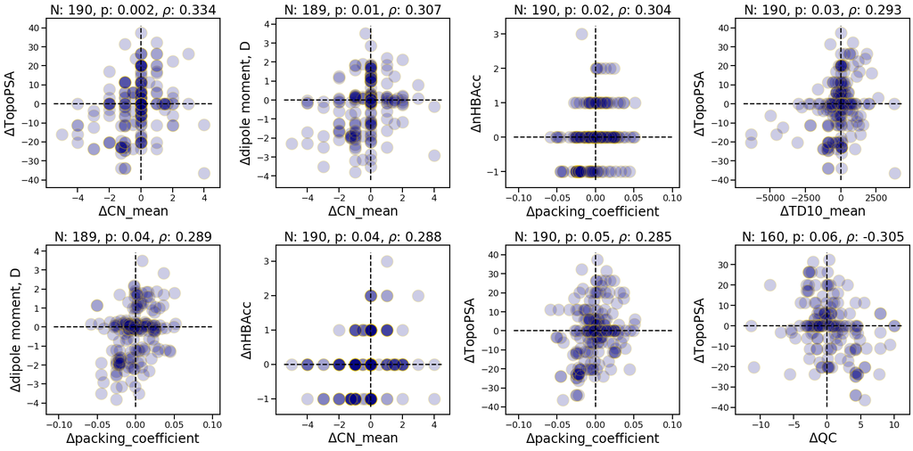

```python
N = 8
fig, ax = plt.subplots(nrows=2, ncols=4, figsize=(24, 12))

for i, (_, (d1, d2, p_val)) in enumerate(corr_df.sort_values(by=['p_value_corr', 'p_value'], ascending=True).head(N)[['crystal desc', 'solvent desc', 'p_value_corr']].iterrows()):
    axis = ax[i//4, i%4]

    c_df = correlation_df[[d1, d2]].dropna()

    axis.scatter(c_df[d1], c_df[d2], s=500, alpha=.2, color='navy', edgecolor='gold')
    axis.hlines(0, *axis.get_xlim(), colors='k', linestyles='dashed')
    axis.vlines(0, *axis.get_ylim(), colors='k', linestyles='dashed')

    axis.set_title(r'N: {}, p: {:.1g}, $\rho$: {:.3f}'.format(c_df.shape[0], p_val,
                                                              spearmanr(c_df[d1], c_df[d2])[0]),
                   fontdict=dict(fontsize=24))
    axis.set_xlabel(r'$\Delta$' + d1.replace('_px', ''), fontdict=dict(fontsize=24))
    axis.set_ylabel(r'$\Delta$' + d2, fontdict=dict(fontsize=24))

fig.tight_layout()
```

Более подробное описание и обсуждение полученных результатов статистического анализа представлено в статье [On the Influence of Solvent Properties on the Structural Characteristics of Molecular Crystal Polymorphs, Cryst. Growth Des. 2020, 20, 11, 7152–7162](https://pubs.acs.org/doi/10.1021/acs.cgd.0c00753)